# Dictator Game

Author

Liam Doyle

## Description

This document is a summary of the analyses performed for the fourth meta-analytic model conducted in Study 1 of my dissertation. This model examined the relationship between psychopathy and exploitative behavior in the Dictator Game.

This model utilized a multi-level or hierarchical approach in order to deal with the issue of nested effect sizes (i.e., some studies contributing more than one effect size to the analysis).

## Loading Packages

All relevant packages loaded below.

```r
library(tidyverse)
library(meta)
library(metafor)
library(devtools)
library(esc)
library(effectsize)
library(psych)
library(dmetar)
library(readxl)
```

## Loading Data

Loading the excel spreadsheet with all study information.

```r
DG <- read_excel("DG.xlsx")
```

## Recoding Variables as Factors

Recoding relevant variables (i.e., moderators in the analysis) as factors.

```r
DG$Sample_Source <- factor(DG$Sample_Source,
                                  levels = c(0, 1, 2, 3),
                                  labels = c("Community", "Student", "Inmate", "Mixed"))

DG$Publication_Status <- factor(DG$Publication_Status,
                                       levels = c(0, 1),
                                       labels = c("Unpublished", "Published"))

DG$Measure_coded <- factor(DG$Measure_coded,
                                       levels = c(0, 1, 2, 3, 4, 5, 6),
                                       labels = c("SRP", "PCL", "PPI",
                                                  "LSRP", "TriPM", "SD3",
                                                  "DD"))

DG$Iterated <- factor(DG$Iterated,
                                       levels = c(0, 1),
                                       labels = c("One-shot", "Iterated"))

DG$Perceived_Opponent <- factor(DG$Perceived_Opponent,
                                 levels = c(0, 1),
                                 labels = c("No", "Yes"))

DG$Social_role <- factor(DG$Social_role,
                                       levels = c(0, 1),
                                       labels = c("Close member", "Distant member"))

DG$Incentives <- factor(DG$Incentives,
                               levels = c(0, 1, 2),
                               labels = c("Not incentivized", "Participation incentivized",
                                          "Performance incentivized"))

DG$Experimental_Manipulation <- factor(DG$Experimental_Manipulation,
                                                levels = c(0, 1),
                                                labels = c("No Manipulation",
                                                           "Manipulation"))
```

## Computing Additional Variables

Performing mathematical computations to compute relevant variables such as Fisher’s *z*, as well as it’s standard error and variance.

```r
DG <- DG %>%
  mutate(z_psyc_coop = 0.5 * log((1 + Psych_Coop)/(1 - Psych_Coop)))

DG <- DG %>%
  mutate(z_se_psyc_coop = 1/(sqrt(n_effect - 3)))

DG <- DG %>%
  mutate(var_z_psyc_coop = (z_se_psyc_coop^2))
```

## Multi-Level Random-Effects Model of Psychopathy on Cooperation in the Dictator Game

As noted in the heading and the project description, this model utilizes a multi-level or hierarchical approach to modelling the relationship between psychopathy and cooperation in the Dictator Game. This is due to the fact that several of the studies included in the meta-analysis contributed more than one effect size to the analysis (e.g., a study using more than one measure of psychopathy). The contemporary recommendation for addressing this issue is to use a multi-level approach to cluster these data points - rather than simply aggregating them and ignoring potential differences between the effects.

In addition, I have made the decision to use a random-effects model for the meta-analyses in this dissertation. The fixed-effects model makes untenable assumptions about the sources of variance in the effect sizes (i.e., assuming that all effect sizes are from a homogenous population, and the only source of variance in effect sizes is from sampling error). The assumptions of a fixed-effects model also stand in contradiction to the intended moderator analyses which make up a substantial portion of our later analyses.

### Creation of the Model

```r
full.model <- rma.mv(yi = z_psyc_coop,
                     V = var_z_psyc_coop,
                     slab = Study,
                     data = DG,
                     random = ~ 1 | Study/Effect_size_ID,
                     test = "t",
                     method = "REML")

summary(full.model)
```

```
Multivariate Meta-Analysis Model (k = 23; method: REML)

  logLik  Deviance       AIC       BIC      AICc
 17.0990  -34.1979  -28.1979  -24.9248  -26.8646

Variance Components:

            estim    sqrt  nlvls  fixed                factor
sigma^2.1  0.0000  0.0000     21     no                 Study
sigma^2.2  0.0063  0.0796     23     no  Study/Effect_size_ID

Test for Heterogeneity:
Q(df = 22) = 66.0884, p-val < .0001

Model Results:

estimate      se     tval  df    pval    ci.lb    ci.ub
 -0.1728  0.0228  -7.5782  22  <.0001  -0.2201  -0.1255  ***

---
Signif. codes:  0 '***' 0.001 '**' 0.01 '*' 0.05 '.' 0.1 ' ' 1
```

```r
convert_z2r(-.1728)
```

```
[1] -0.1711004
```

As we can see, the model estimates that the meta-analytic effect size is *r* = -.171, 95% CI [-.220, -.126]. Cochran’s *Q* statistic was significant (*p* < .0001), indicating potential between-study heterogeneity.

### Distribution of Variance Across Levels

This function, provided by the package *dmetar*, calculates a multilevel version of I2. Level 1 variance corresponds to sampling error variance. Level 2 variance corresponds to within-study (or cluster) variance. Level 3 variance corresponds to between-study variance.

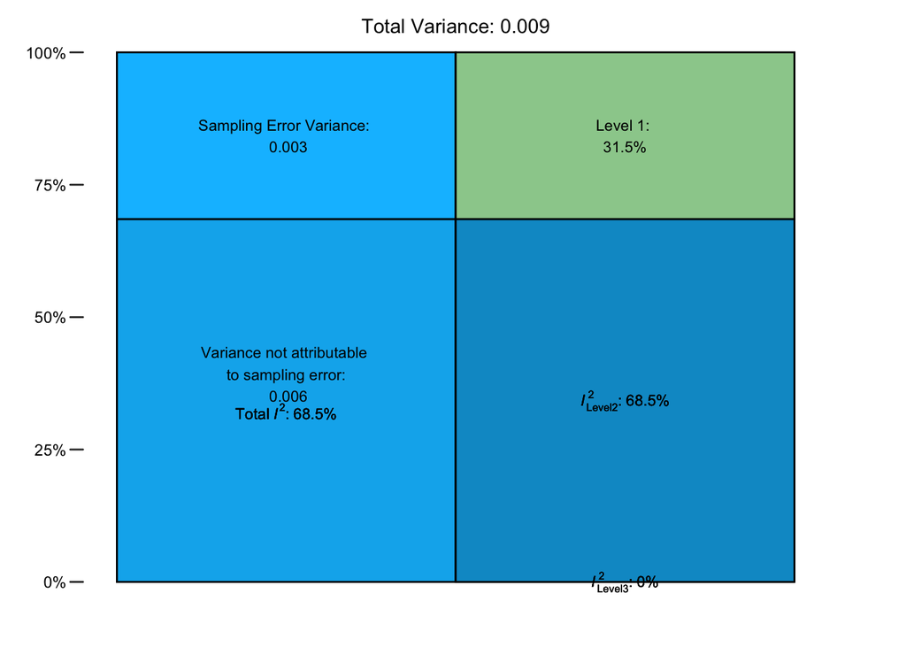

```r
i2 <- var.comp(full.model)

plot(i2)
```

In our case, roughly 68.5% of the variation between effect sizes can be attributed to within-study. According to the multi-level model, none of the variation between effect sizes is due to between-study heterogeneity. Rather, the remaining variance has been attributed to sampling error. This *I*<sup>2</sup> value is considered to represent a substantial amount of heterogeneity.

### Comparing Models

```r
l3.removed <- rma.mv(yi = z_psyc_coop,
                     V = var_z_psyc_coop,
                     slab = Study,
                     data = DG,
                     random = ~ 1 | Study/Effect_size_ID,
                     test = "t",
                     method = "REML",
                     sigma2 = c(0, NA))

anova(full.model, l3.removed)
```

```
        df      AIC      BIC     AICc  logLik    LRT   pval      QE
Full     3 -28.1979 -24.9248 -26.8646 17.0990               66.0884
Reduced  2 -30.1979 -28.0159 -29.5664 17.0990 0.0000 1.0000 66.0884
```

### Forest Plot of the Model

Note: This plot had to be generated using a simple random-effects meta-analytic model, as there is not a package available in *R* to accommodate the creation of forest plots for multi-level meta-analytic models.

```r
psyc.coop <- metacor(cor = Psych_Coop,
                 n = n_effect,
                 studlab = Study,
                 data = DG,
                 fixed = FALSE,
                 random = TRUE,
                 method.tau = "REML",
                 method.random.ci = "HK",
                 title = "Psychopathy and Cooperation in the DG")

png(file = "forestplot.png", width = 2800, height = 2400, res = 300)

meta::forest(psyc.coop,
             sortvar = Psych_Coop,
             prediction = TRUE,
             print.tau2 = TRUE,
             width = 1000)

dev.off()
```

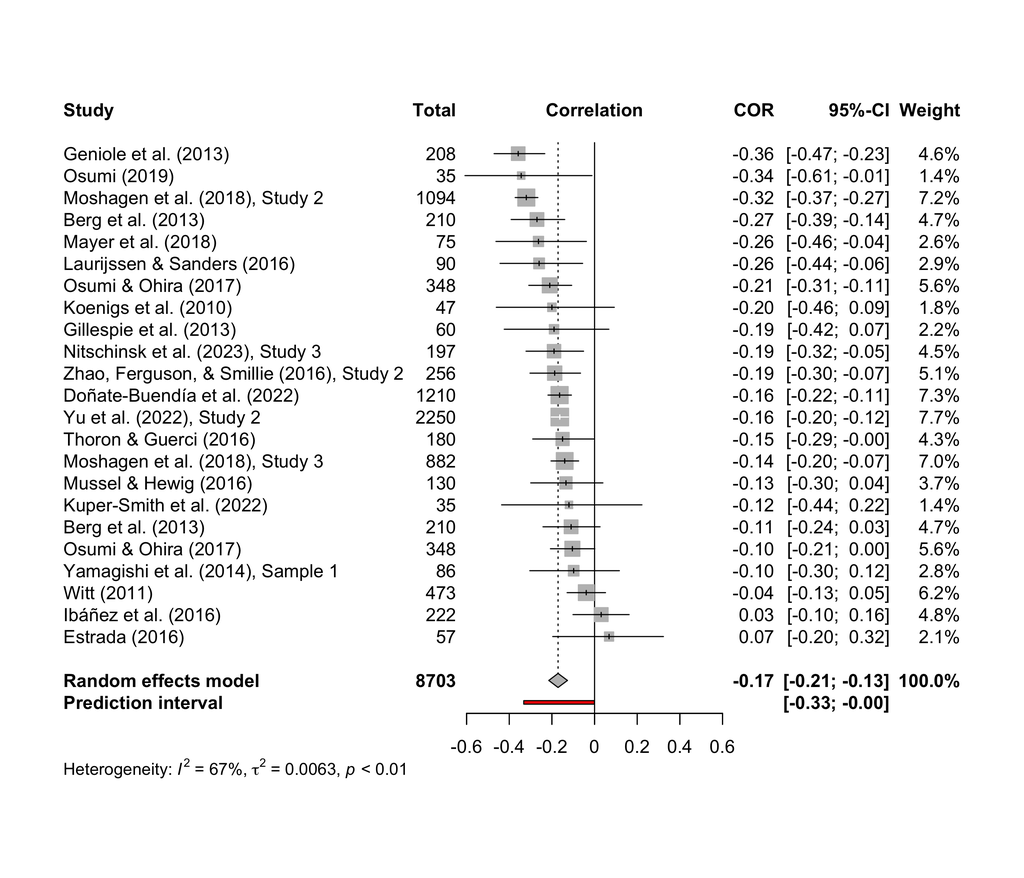

```r
knitr::include_graphics("forestplot.png")
```

## Tests of Publication Bias

In this section, I examined the possibility of publication bias via the visual examination of funnel plots, Egger’s regression test, a simple meta-regression which regressed publication status (as a binary factor) on effect size, and PET-PEESE methods.

### Funnel Plot

While this funnel plot does possess a small degree of asymmetry, it should be noted that our *I*<sup>2</sup> value indicated a substantial amount of heterogeneity between effect sizes (i.e., 68.5% of the variation between effect sizes was due to within-study and between-study heterogeneity). Asymmetry in a funnel plot has several possible sources (Page et al., 2020):

- Publication bias and other reporting biases;
- Variability in methodological quality;
- Between-study heterogeneity;
- Artefactual variance (i.e., via the correlation between effect sizes and their standard error)
- Chance

While it is certainly possible that the asymmetry is attributable to publication bias, there are also potential explanations for the phenomenon.

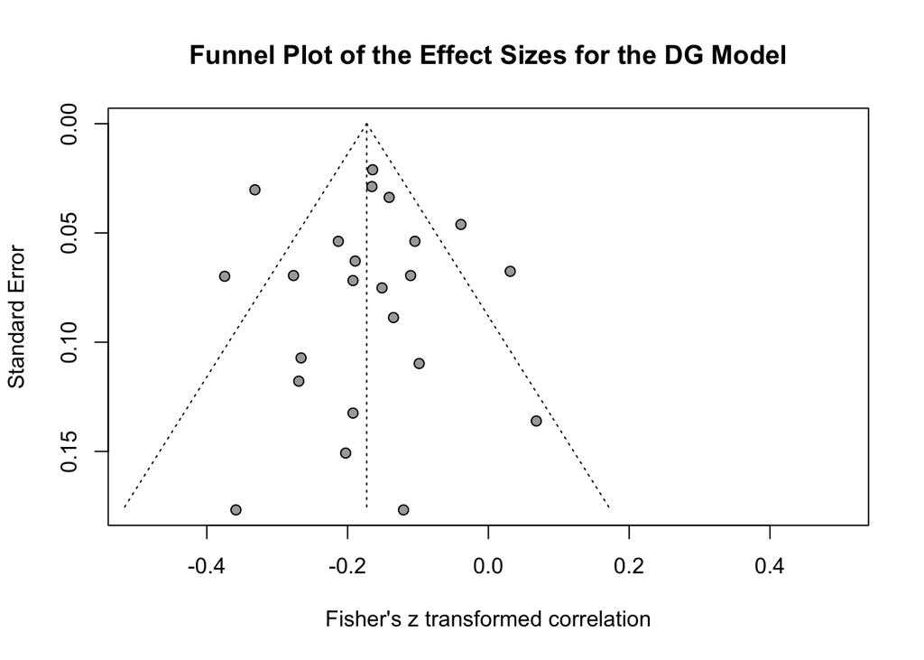

```r
meta::funnel(psyc.coop,
             xlim = c(-.5, .5),
             studlab = FALSE)

title("Funnel Plot of the Effect Sizes for the DG Model")
```

### Egger’s Regression Test

Egger’s regression test (Egger et al., 1997) is a method that provides a statistical test of asymmetry in a funnel plot. It involves the prediction of standardized effect sizes on their precision.

The intercept (i.e., $\beta_0$) is of primary interest, representing the asymmetry of the plot. NHST can be used to test the null hypothesis that the intercept is equal to zero, indicating symmetry in the funnel plot. Conversely, a rejected null hypothesis for the intercept indicates asymmetry in the funnel plot - potentially due to publication bias.

The slope (i.e., $\beta_1$) represents the effect size adjusted for precision. It is expected to be consistent with the overall meta-analytic effect.

Reported below is the significance test and parameter estimate for the intercept.

```r
metabias(psyc.coop,
         method.bias = "linreg")
```

```
Review:     Psychopathy and Cooperation in the DG

Linear regression test of funnel plot asymmetry

Test result: t = 0.31, df = 21, p-value = 0.7593
Bias estimate: 0.2131 (SE = 0.6863)

Details:
- multiplicative residual heterogeneity variance (tau^2 = 3.1327)
- predictor: standard error
- weight:    inverse variance
- reference: Egger et al. (1997), BMJ
```

The intercept was not significant, indicating that there is not a substantial amount of asymmetry in the funnel plot.

### Publication Status as a Moderator of Effect Size

Simple meta-regression was used to predict effect sizes from publication status as a factor (i.e., 0 = unpublished, 1 = published).

```r
mod.model.pub <- rma.mv(yi = z_psyc_coop,
                        V = var_z_psyc_coop,
                        slab = Study,
                        data = DG,
                        random = ~ 1 | Study/Effect_size_ID,
                        test = "t",
                        method = "REML",
                        mods = ~ Publication_Status)

summary(mod.model.pub)
```

```
Multivariate Meta-Analysis Model (k = 23; method: REML)

  logLik  Deviance       AIC       BIC      AICc
 17.2026  -34.4053  -26.4053  -22.2272  -23.9053

Variance Components:

            estim    sqrt  nlvls  fixed                factor
sigma^2.1  0.0000  0.0000     21     no                 Study
sigma^2.2  0.0058  0.0762     23     no  Study/Effect_size_ID

Test for Residual Heterogeneity:
QE(df = 21) = 59.1730, p-val < .0001

Test of Moderators (coefficient 2):
F(df1 = 1, df2 = 21) = 2.8628, p-val = 0.1054

Model Results:

                             estimate      se     tval  df    pval    ci.lb
intrcpt                       -0.1007  0.0481  -2.0926  21  0.0487  -0.2007
Publication_StatusPublished   -0.0918  0.0542  -1.6920  21  0.1054  -0.2045
                               ci.ub
intrcpt                      -0.0006  *
Publication_StatusPublished   0.0210

---
Signif. codes:  0 '***' 0.001 '**' 0.01 '*' 0.05 '.' 0.1 ' ' 1
```

The omnibus test indicates that there is no significant difference between published and unpublished studies, *F*(1, 21) = 2.86, *p* = .105. That said, it is close to being a trend towards significance (i.e., *p* < .10). The estimates that unpublished studies have a parameter of *r* = -.101, and published studies have a parameter of *r* = -.193.

### PET & PEESE Analyses

The PET (Precision-Effect Test) and PEESE (Precision-Effect Estimate with Standard Error) are two analytical methods designed to address publication bias in meta-analyses.

The former, PET analysis, is designed to determine the degree to which small-study effects and publication bias impact a meta-analysis. To do so, effect sizes are predicted from their standard errors. This analysis is used to provide evidence that a genuine effect exists beyond the effect of small-study effects/publication bias.

#### PET Analysis

The key element of the PET analysis is the estimate for $\beta_0$ or the intercept of the regression. According to the logic for PET analysis, a non-significant intercept indicates that no genuine effect occurs beyond small-study effects/publication bias. In contrast, a significant intercept provides evidence for a true effect.

That being said, one potential issue with both PET and PEESE analysis is the assumption that there is a homogenous distribution underlying effect sizes. Conceptually, this is similar to the assumption underlying fixed-effects meta-analyses (https://willgervais.com/blog/2015/6/25/putting-pet-peese-to-the-test-1). While this is problematic in and of itself, we will proceed using the PET-PEESE method.

```r
pet_model <- rma.mv(yi = z_psyc_coop,
                    V = var_z_psyc_coop,
                    mods = ~ z_se_psyc_coop,
                    slab = Study,
                    data = DG,
                    random = ~ 1 | Study/Effect_size_ID,
                    test = "t",
                    method = "REML")

summary(pet_model)
```

```
Multivariate Meta-Analysis Model (k = 23; method: REML)

  logLik  Deviance       AIC       BIC      AICc
 16.0211  -32.0422  -24.0422  -19.8641  -21.5422

Variance Components:

            estim    sqrt  nlvls  fixed                factor
sigma^2.1  0.0000  0.0000     21     no                 Study
sigma^2.2  0.0067  0.0819     23     no  Study/Effect_size_ID

Test for Residual Heterogeneity:
QE(df = 21) = 65.7865, p-val < .0001

Test of Moderators (coefficient 2):
F(df1 = 1, df2 = 21) = 0.0018, p-val = 0.9665

Model Results:

                estimate      se     tval  df    pval    ci.lb    ci.ub
intrcpt          -0.1746  0.0479  -3.6434  21  0.0015  -0.2742  -0.0749  **
z_se_psyc_coop    0.0270  0.6344   0.0425  21  0.9665  -1.2923   1.3462

---
Signif. codes:  0 '***' 0.001 '**' 0.01 '*' 0.05 '.' 0.1 ' ' 1
```

As seen in the output, the intercept in the model is significant (*p* = .002). This indicates that a true effect exists. According to the PET-PEESE method, we should proceed to the PEESE step of modelling.

#### PEESE Analysis

PEESE analysis aims to produce a precise estimate of the true effect size after accounting for sampling error, small-study effects, and publication bias. It does so by creating a regression where effect sizes are predicted by the squared standard errors of studies.

Again, the primary parameter estimate of interest is $\beta_0$, which indicates the estimate of the true effect size (after adjusting for sampling error, small-study effects, and publication bias). Significance tests are interpreted such that a significant intercept indicates a significant meta-analytic effect size.

A secondary parameter estimate of interest is $\beta_1$, which indicates the relationship between effect sizes and their variances. When this is significant, there is evidence that effect sizes are systematically related to the estimate of their precision (i.e., their variance), which may suggest the presence of small-study effects or publication bias.

More particularly, a negative slope indicates that smaller studies (with larger standard errors by necessity) report larger effect sizes. This is representative of the typical “small-study effect” and indicates potential publication bias.

In contrast, a positive slope suggests that smaller studies report smaller effect sizes. This indicates other sources of bias or sources of heterogeneity impacting the results.

```r
peese_model <- rma.mv(yi = z_psyc_coop,
                      V = var_z_psyc_coop,
                      mods = ~ var_z_psyc_coop,
                      slab = Study,
                      data = DG,
                      random = ~ 1 | Study/Effect_size_ID,
                      test = "t",
                      method = "REML")

summary(peese_model)
```

```
Multivariate Meta-Analysis Model (k = 23; method: REML)

  logLik  Deviance       AIC       BIC      AICc
 16.1401  -32.2803  -24.2803  -20.1022  -21.7803

Variance Components:

            estim    sqrt  nlvls  fixed                factor
sigma^2.1  0.0000  0.0000     21     no                 Study
sigma^2.2  0.0066  0.0814     23     no  Study/Effect_size_ID

Test for Residual Heterogeneity:
QE(df = 21) = 65.9980, p-val < .0001

Test of Moderators (coefficient 2):
F(df1 = 1, df2 = 21) = 0.0065, p-val = 0.9365

Model Results:

                 estimate      se     tval  df    pval    ci.lb    ci.ub
intrcpt           -0.1712  0.0306  -5.5955  21  <.0001  -0.2348  -0.1076  ***
var_z_psyc_coop   -0.2838  3.5173  -0.0807  21  0.9365  -7.5984   7.0309

---
Signif. codes:  0 '***' 0.001 '**' 0.01 '*' 0.05 '.' 0.1 ' ' 1
```

```r
convert_z2r(-.1712)
```

```
[1] -0.1695468
```

As seen in the model output, the PEESE method indicates that the true effect size is *r* = -.170 and significant at *p* < .0001. This differs only very slightly from our original estimate of the effect at *r* = -.171.

The slope coefficient indicates a non-significant, negative relationship between effect sizes and their variances (see above). The fact that this relationship is not significant indicates that publication bias does not have a substantial impact on the effect sizes.

To illustrate the slope estimated by the model visually, we will plot the regression.

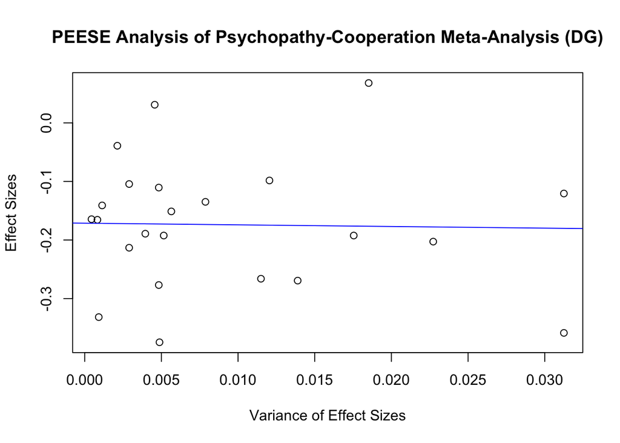

```r
plot(
  DG$var_z_psyc_coop, DG$z_psyc_coop,
  xlab = "Variance of Effect Sizes",
  ylab = "Effect Sizes",
  main = "PEESE Analysis of Psychopathy-Cooperation Meta-Analysis (DG)"
)
abline(a = coef(peese_model)[1], b = coef(peese_model)[2], col = "blue")
```

### Fail-Safe *N*

A variation of Orwin’s (1983) fail-safe N test was used to indicate the number of studies with null effects needed to reduce the effect size to a practically irrelevant size (Viechtbauer, 2010). Practical insignificance was demarked by an effect size of r = |.05|, depending on the direction of the summary effect.

```r
fail.safe <- rma(yi = z_psyc_coop,
                 vi = var_z_psyc_coop,
                 slab = Study,
                 data = DG,
                 test = "t",
                 method = "REML")

fsn(fail.safe, type = "General", target = 0.05)
```

```
Fail-safe N Calculation Using the General Approach

Average Effect Size:         -0.1728 (with file drawer: -0.0499)
Amount of Heterogeneity:      0.0063 (with file drawer:  0.0120)
Observed Significance Level:  <.0001 (with file drawer:  0.0016)
Target Effect Size:          -0.0500

Fail-safe N: 46
```

## Moderator Analysis

Afterwards, a series of moderators were tested. The list of moderators was generated *a priori* using the Affordance-Based Framework of Prosocial Behavior, original ideas, and ideas from previous meta-analyses on psychopathy and cooperation (e.g., Thielmann et al., 2020). In-depth reasoning for the selection of moderators is provided in the dissertation package.

Multiple meta-regression was not used in our study due to constraints arising from (a) a smaller numbers of studies being used (b) the large number of moderators being considered (Higgins & Thompson, 2004). As such, our study explored individual moderators with simple meta-regression analysis. For each model where there were over 10 studies (Deeks et al., 2023), moderators of interest were examined individually using simple meta-regression.

As the current model had 23 effect sizes, simple meta-regression was used to test the list of moderators. The results are shown below.

### *N* as a Moderator of Effect Size

```r
mod.model.n <- rma.mv(yi = z_psyc_coop,
                             V = var_z_psyc_coop,
                             slab = Study,
                             data = DG,
                             random = ~ 1 | Study/Effect_size_ID,
                             test = "t",
                             method = "REML",
                             mods = ~ n_effect)

summary(mod.model.n)
```

```
Multivariate Meta-Analysis Model (k = 23; method: REML)

  logLik  Deviance       AIC       BIC      AICc
 15.6954  -31.3908  -23.3908  -19.2127  -20.8908

Variance Components:

            estim    sqrt  nlvls  fixed                factor
sigma^2.1  0.0000  0.0000     21     no                 Study
sigma^2.2  0.0069  0.0833     23     no  Study/Effect_size_ID

Test for Residual Heterogeneity:
QE(df = 21) = 65.9835, p-val < .0001

Test of Moderators (coefficient 2):
F(df1 = 1, df2 = 21) = 0.0868, p-val = 0.7712

Model Results:

          estimate      se     tval  df    pval    ci.lb    ci.ub
intrcpt    -0.1665  0.0316  -5.2676  21  <.0001  -0.2323  -0.1008  ***
n_effect   -0.0000  0.0000  -0.2946  21  0.7712  -0.0001   0.0001

---
Signif. codes:  0 '***' 0.001 '**' 0.01 '*' 0.05 '.' 0.1 ' ' 1
```

### Sex Composition as a Moderator of Effect Size

Note: sex composition was a variable represented as the proportion of participants who identified as female in the study.

```r
mod.model.sex <- rma.mv(yi = z_psyc_coop,
                        V = var_z_psyc_coop,
                        slab = Study,
                        data = DG,
                        random = ~ 1 | Study/Effect_size_ID,
                        test = "t",
                        method = "REML",
                        mods = ~ Sex_female)
summary(mod.model.sex)
```

```
Multivariate Meta-Analysis Model (k = 22; method: REML)

  logLik  Deviance       AIC       BIC      AICc
 14.7889  -29.5777  -21.5777  -17.5948  -18.9111

Variance Components:

            estim    sqrt  nlvls  fixed                factor
sigma^2.1  0.0000  0.0000     20     no                 Study
sigma^2.2  0.0072  0.0847     22     no  Study/Effect_size_ID

Test for Residual Heterogeneity:
QE(df = 20) = 65.8851, p-val < .0001

Test of Moderators (coefficient 2):
F(df1 = 1, df2 = 20) = 0.0000, p-val = 0.9978

Model Results:

            estimate      se     tval  df    pval    ci.lb    ci.ub
intrcpt      -0.1739  0.0696  -2.4988  20  0.0213  -0.3191  -0.0287  *
Sex_female    0.0003  0.1244   0.0027  20  0.9978  -0.2591   0.2597

---
Signif. codes:  0 '***' 0.001 '**' 0.01 '*' 0.05 '.' 0.1 ' ' 1
```

### Mean Age as a Moderator of Effect Size

```r
mod.model.age <- rma.mv(yi = z_psyc_coop,
                        V = var_z_psyc_coop,
                        slab = Study,
                        data = DG,
                        random = ~ 1 | Study/Effect_size_ID,
                        test = "t",
                        method = "REML",
                        mods = ~ Age)
summary(mod.model.age)
```

```
Multivariate Meta-Analysis Model (k = 18; method: REML)

  logLik  Deviance       AIC       BIC      AICc
 11.0532  -22.1063  -14.1063  -11.0160  -10.4700

Variance Components:

            estim    sqrt  nlvls  fixed                factor
sigma^2.1  0.0000  0.0000     16     no                 Study
sigma^2.2  0.0081  0.0897     18     no  Study/Effect_size_ID

Test for Residual Heterogeneity:
QE(df = 16) = 53.3967, p-val < .0001

Test of Moderators (coefficient 2):
F(df1 = 1, df2 = 16) = 0.0185, p-val = 0.8934

Model Results:

         estimate      se     tval  df    pval    ci.lb    ci.ub
intrcpt   -0.1987  0.0909  -2.1866  16  0.0440  -0.3914  -0.0061  *
Age        0.0004  0.0033   0.1361  16  0.8934  -0.0065   0.0074

---
Signif. codes:  0 '***' 0.001 '**' 0.01 '*' 0.05 '.' 0.1 ' ' 1
```

### Sample Source as a Moderator of Effect Size

Note: Studies were coded such that:

- 0 = Community;
- 1 = Student;
- 2 = Inmate;
- 3 = Mixed

```r
mod.model.sample <- rma.mv(yi = z_psyc_coop,
                           V = var_z_psyc_coop,
                           slab = Study,
                           data = DG,
                           random = ~ 1 | Study/Effect_size_ID,
                           test = "t",
                           method = "REML",
                           mods = ~ Sample_Source)
summary(mod.model.sample)
```

```
Multivariate Meta-Analysis Model (k = 21; method: REML)

  logLik  Deviance       AIC       BIC      AICc
 11.6177  -23.2353  -11.2353   -6.2360   -2.8353

Variance Components:

            estim    sqrt  nlvls  fixed                factor
sigma^2.1  0.0000  0.0000     19     no                 Study
sigma^2.2  0.0084  0.0917     21     no  Study/Effect_size_ID

Test for Residual Heterogeneity:
QE(df = 17) = 57.3385, p-val < .0001

Test of Moderators (coefficients 2:4):
F(df1 = 3, df2 = 17) = 0.1906, p-val = 0.9013

Model Results:

                      estimate      se     tval  df    pval    ci.lb    ci.ub
intrcpt                -0.1838  0.0421  -4.3670  17  0.0004  -0.2727  -0.0950
Sample_SourceStudent    0.0218  0.0557   0.3905  17  0.7010  -0.0958   0.1393
Sample_SourceInmate     0.0172  0.1386   0.1244  17  0.9025  -0.2752   0.3097
Sample_SourceMixed     -0.0855  0.1551  -0.5510  17  0.5888  -0.4128   0.2418

intrcpt               ***
Sample_SourceStudent
Sample_SourceInmate
Sample_SourceMixed

---
Signif. codes:  0 '***' 0.001 '**' 0.01 '*' 0.05 '.' 0.1 ' ' 1
```

### Psychopathy Measure as a Moderator of Effect Size

Note: Studies were coded such that:

- 0 = SRP;
- 1 = PCL;
- 2 = PPI;
- 3 = LSRP;
- 4 = TriPM;
- 5 = SD3;
- 6 = DD

```r
mod.model.measure <- rma.mv(yi = z_psyc_coop,
                            V = var_z_psyc_coop,
                            slab = Study,
                            data = DG,
                            random = ~ 1 | Study/Effect_size_ID,
                            test = "t",
                            method = "REML",
                            mods = ~ Measure_coded)
summary(mod.model.measure)
```

```
Multivariate Meta-Analysis Model (k = 21; method: REML)

  logLik  Deviance       AIC       BIC      AICc
  9.1514  -18.3028   -0.3028    5.4487   44.6972

Variance Components:

            estim    sqrt  nlvls  fixed                factor
sigma^2.1  0.0000  0.0000     19     no                 Study
sigma^2.2  0.0089  0.0941     21     no  Study/Effect_size_ID

Test for Residual Heterogeneity:
QE(df = 14) = 50.8437, p-val < .0001

Test of Moderators (coefficients 2:7):
F(df1 = 6, df2 = 14) = 0.4460, p-val = 0.8361

Model Results:

                    estimate      se     tval  df    pval    ci.lb   ci.ub
intrcpt              -0.1096  0.0599  -1.8309  14  0.0885  -0.2380  0.0188  .
Measure_codedPCL     -0.0569  0.1458  -0.3905  14  0.7021  -0.3696  0.2558
Measure_codedPPI     -0.0971  0.0935  -1.0384  14  0.3167  -0.2977  0.1035
Measure_codedLSRP    -0.0521  0.0752  -0.6935  14  0.4994  -0.2134  0.1091
Measure_codedTriPM   -0.0252  0.1425  -0.1768  14  0.8622  -0.3309  0.2805
Measure_codedSD3     -0.1160  0.0851  -1.3635  14  0.1942  -0.2985  0.0665
Measure_codedDD      -0.1565  0.1547  -1.0115  14  0.3289  -0.4883  0.1753

---
Signif. codes:  0 '***' 0.001 '**' 0.01 '*' 0.05 '.' 0.1 ' ' 1
```

### One-Shot vs. Iterated as a Moderator of Effect Size

Note: Studies were coded such that:

- 0 = one-shot;
- 1 = iterated

```r
mod.model.iterated <- rma.mv(yi = z_psyc_coop,
                             V = var_z_psyc_coop,
                             slab = Study,
                             data = DG,
                             random = ~ 1 | Study/Effect_size_ID,
                             test = "t",
                             method = "REML",
                             mods = ~ Iterated)

summary(mod.model.iterated)
```

```
Multivariate Meta-Analysis Model (k = 23; method: REML)

  logLik  Deviance       AIC       BIC      AICc
 15.8243  -31.6485  -23.6485  -19.4704  -21.1485

Variance Components:

            estim    sqrt  nlvls  fixed                factor
sigma^2.1  0.0000  0.0000     21     no                 Study
sigma^2.2  0.0069  0.0832     23     no  Study/Effect_size_ID

Test for Residual Heterogeneity:
QE(df = 21) = 65.6125, p-val < .0001

Test of Moderators (coefficient 2):
F(df1 = 1, df2 = 21) = 0.0273, p-val = 0.8704

Model Results:

                  estimate      se     tval  df    pval    ci.lb    ci.ub
intrcpt            -0.1710  0.0259  -6.6090  21  <.0001  -0.2248  -0.1172  ***
IteratedIterated   -0.0102  0.0615  -0.1652  21  0.8704  -0.1380   0.1177

---
Signif. codes:  0 '***' 0.001 '**' 0.01 '*' 0.05 '.' 0.1 ' ' 1
```

### Perceived Opponent as a Moderator of Effect Size

Note: Studies were coded such that:

- 0 = participants were *not* led to believe that their opponent was human;
- 1 = participants *were* led to believe that their opponent was human

```r
mod.model.perceive <- rma.mv(yi = z_psyc_coop,
                             V = var_z_psyc_coop,
                             slab = Study,
                             data = DG,
                             random = ~ 1 | Study/Effect_size_ID,
                             test = "t",
                             method = "REML",
                             mods = ~ Perceived_Opponent)

summary(mod.model.perceive)
```

```
Multivariate Meta-Analysis Model (k = 23; method: REML)

  logLik  Deviance       AIC       BIC      AICc
 16.7510  -33.5021  -25.5021  -21.3240  -23.0021

Variance Components:

            estim    sqrt  nlvls  fixed                factor
sigma^2.1  0.0000  0.0000     21     no                 Study
sigma^2.2  0.0054  0.0738     23     no  Study/Effect_size_ID

Test for Residual Heterogeneity:
QE(df = 21) = 50.8710, p-val = 0.0003

Test of Moderators (coefficient 2):
F(df1 = 1, df2 = 21) = 2.0899, p-val = 0.1630

Model Results:

                       estimate      se     tval  df    pval    ci.lb    ci.ub
intrcpt                 -0.2105  0.0339  -6.2118  21  <.0001  -0.2809  -0.1400
Perceived_OpponentYes    0.0639  0.0442   1.4457  21  0.1630  -0.0280   0.1559

intrcpt                ***
Perceived_OpponentYes

---
Signif. codes:  0 '***' 0.001 '**' 0.01 '*' 0.05 '.' 0.1 ' ' 1
```

### Social Role of Opponent as a Moderator of Effect Size

Note: Studies were coded such that:

- 0 = The participants’ perceived opponent was a close member of their social circle (e.g., friend, in-group member);
- 1 = The participants’ perceived opponent was a distant member of their social circle (e.g., stranger, out-group member)

```r
mod.model.social <- rma.mv(yi = z_psyc_coop,
                           V = var_z_psyc_coop,
                           slab = Study,
                           data = DG,
                           random = ~ 1 | Study/Effect_size_ID,
                           test = "t",
                           method = "REML",
                           mods = ~ Social_role)
summary(mod.model.social)
```

```
Multivariate Meta-Analysis Model (k = 18; method: REML)

  logLik  Deviance       AIC       BIC      AICc
 10.8152  -21.6304  -13.6304  -10.5401   -9.9941

Variance Components:

            estim    sqrt  nlvls  fixed                factor
sigma^2.1  0.0000  0.0000     17     no                 Study
sigma^2.2  0.0085  0.0921     18     no  Study/Effect_size_ID

Test for Residual Heterogeneity:
QE(df = 16) = 61.3526, p-val < .0001

Test of Moderators (coefficient 2):
F(df1 = 1, df2 = 16) = 0.1581, p-val = 0.6962

Model Results:

                           estimate      se     tval  df    pval    ci.lb
intrcpt                     -0.1444  0.0787  -1.8338  16  0.0854  -0.3113
Social_roleDistant member   -0.0335  0.0842  -0.3976  16  0.6962  -0.2120
                            ci.ub
intrcpt                    0.0225  .
Social_roleDistant member  0.1450

---
Signif. codes:  0 '***' 0.001 '**' 0.01 '*' 0.05 '.' 0.1 ' ' 1
```

### Incentive Structure as a Moderator of Effect Size

Note: Studies were coded such that:

- 0 = The study was not incentivized;
- 1 = Participation was incentivized;
- 2 = Performance was incentivized

```r
mod.model.incentive <- rma.mv(yi = z_psyc_coop,
                              V = var_z_psyc_coop,
                              slab = Study,
                              data = DG,
                              random = ~ 1 | Study/Effect_size_ID,
                              test = "t",
                              method = "REML",
                              mods = ~ Incentives)

summary(mod.model.incentive)
```

```
Multivariate Meta-Analysis Model (k = 23; method: REML)

  logLik  Deviance       AIC       BIC      AICc
 15.1287  -30.2573  -20.2573  -15.2787  -15.9716

Variance Components:

            estim    sqrt  nlvls  fixed                factor
sigma^2.1  0.0000  0.0000     21     no                 Study
sigma^2.2  0.0061  0.0783     23     no  Study/Effect_size_ID

Test for Residual Heterogeneity:
QE(df = 20) = 49.1089, p-val = 0.0003

Test of Moderators (coefficients 2:3):
F(df1 = 2, df2 = 20) = 0.6914, p-val = 0.5124

Model Results:

                                      estimate      se     tval  df    pval
intrcpt                                -0.2190  0.0506  -4.3265  20  0.0003
IncentivesParticipation incentivized    0.0395  0.0645   0.6126  20  0.5470
IncentivesPerformance incentivized      0.0697  0.0602   1.1583  20  0.2604
                                        ci.lb    ci.ub
intrcpt                               -0.3246  -0.1134  ***
IncentivesParticipation incentivized  -0.0950   0.1740
IncentivesPerformance incentivized    -0.0558   0.1953

---
Signif. codes:  0 '***' 0.001 '**' 0.01 '*' 0.05 '.' 0.1 ' ' 1
```